# Human and economic costs of US weather disasters

## Synopsis

This document briefly describes some costs of weather events in the United States as measured in the U.S. National Oceanic and Atmospheric Administration’s (NOAA) storm database. Human cost (in terms of injuries and fatalities) and economic cost (in the form of property and crop damage) is reported for the most important types of events underlying these costs.

## Data processing

### Reading data file

The zipped data can be read in using the *read.csv()* function. This requires that the file be in the same folder as this markdown file.

```r
data<- read.csv("repdata_data_StormData.csv.bz2",sep=",")
```

### Extracting relevant information about injuries and fatalities

A first step is to aggregate total fatalities and injuries by event type:

```r
aggFatalities <- aggregate(data$FATALITIES, by=list(data$EVTYPE),FUN=sum)
aggInjuries <- aggregate(data$INJURIES, by=list(data$EVTYPE),FUN=sum)
```

The NOAA storm database contains a total of 935 different event descriptors. As is to be expected, a small number of these event types is responsible for a large fraction[?] of fatalities and injuries, whereas the majority of events caused little to no fatalities or injuries. I therefore chose to list only the ‘top 10’ events in terms of human cost. The other events are lumped into an ‘OTHER’ category.

Using a custom ‘top N categories’ function, we can sort on a given variable and label all categories not in the top N as ‘other’:

```r
## Adds a column to a data set labeling a category either as itself or as OTHER
createTopNcol <- function(data, n=10, categoryCol, countCol, newColName="TOP") {
    ## Sort by relevant column, descending
    result <- data[order(-data[[countCol]]),]

    ## The top n categories keep their old name
    for (i in 1:n) {
        result[i,newColName] <- result[i,categoryCol]
    }
    # The rest is named OTHER
    for (i in 11:nrow(result)) {
        result[i,newColName] <- "OTHER"
    }
    result
    }
## Add a new column for top 10 causes and 'other'
fatalitiesSummarized <- createTopNcol(aggFatalities,n=10, categoryCol="Group.1",countCol="x")
injuriesSummarized <- createTopNcol(aggInjuries,n=10,categoryCol="Group.1",countCol="x")
```

### Extracting an indicator of economic damage

The database gives extimated economic damage in terms of ‘property damage’ (entries in the PROPDMG column, multiplied by a factor specified in the PROPDMGEXP column), and ‘crop damage’ (entries in the CROPDMG column, multiplied by a factor specified in the CROPDMGEXP column).

Since the exponents sometimes come as numbers (e.g. a number 2 in PROPDMGEXP would indicate that a property damage number must be multiplied by 10^2) and sometimes as characters (e.g. the letter M stands for million, i.e. 10ˆ6), we create a function to calculate meaningful dollar values for the property and crop damage estimations.

Having collected this cleaned-up data, we aggregate average property and crop damage, as we did for fatalities and injuries.

```r
## Function to distill a single USD value from the PROPDMG/CROPDMG and corresponding exponent columns
calculateExponent <-function(number,exponentString) {
    exponent <- 0
    if (grepl("[0-9]",exponentString)) {
        exponent <- as.numeric(exponentString)

    } else {
        if (exponentString == "H" || exponentString == "h") {
            exponent = 2
        }
        if (exponentString == "K" || exponentString == "k") {
            exponent = 3
        }
        if (exponentString == "M" || exponentString == "m") {
            exponent = 6
        }
        if (exponentString == "B" || exponentString == "b") {
            exponent = 9
        }
    }

    ## We ignore other characters, such as the pluses and minuses sometimes found.
    ## In that case, the exponent is 0 and the number is multiplied by itself.
    multiplyBy <- 10 ^exponent
    number*multiplyBy
}
# Using mapply(), we can add new columns indicating estimated crop and property damage for
# every event.
data$totalPropDamage <- mapply(calculateExponent,data$PROPDMG, data$PROPDMGEXP)
data$totalCropDamage <- mapply(calculateExponent,data$CROPDMG, data$CROPDMGEXP)

# As before, we create a 'top 10' based on average property and crop damage.
aggPropDamage <- aggregate(data$totalPropDamage, by=list(data$EVTYPE),FUN=mean)
colnames(aggPropDamage)[2] <-"AvgPropDamage"
propDamageSummarized <- createTopNcol(aggPropDamage, n=10, categoryCol="Group.1",countCol="AvgPropDamage")

aggCropDamage <- aggregate(data$totalCropDamage, by=list(data$EVTYPE),FUN=mean)
colnames(aggCropDamage)[2] <-"AvgCropDamage"
cropDamageSummarized <- createTopNcol(aggCropDamage, n=10, categoryCol="Group.1",countCol="AvgCropDamage")
```

## Results

### Fatalities by event type

The following plot shows the number of recorded fatalities for the top 10 most fatal events:

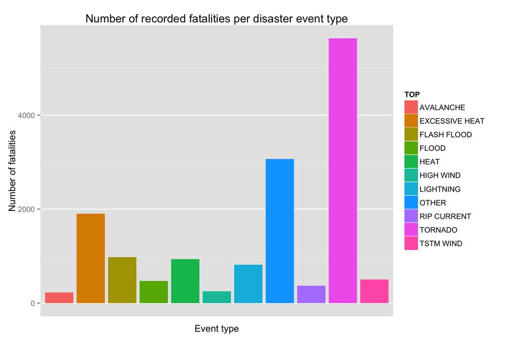

```r
# Uses the ggplot2 library
library(ggplot2)
ggplot(fatalitiesSummarized, aes(x=as.factor(TOP), y=x)) + geom_bar(stat="identity", aes(fill=TOP))  +
    theme(axis.text.x=element_text(angle=-90)) + ggtitle("Number of recorded fatalities per disaster event type") + ylab("Number of fatalities") + xlab("Event type") + scale_x_discrete(breaks=NULL)
```

### Injuries by event type

The following plot shows the number of recorded injuries for the top 10 most injurious events:

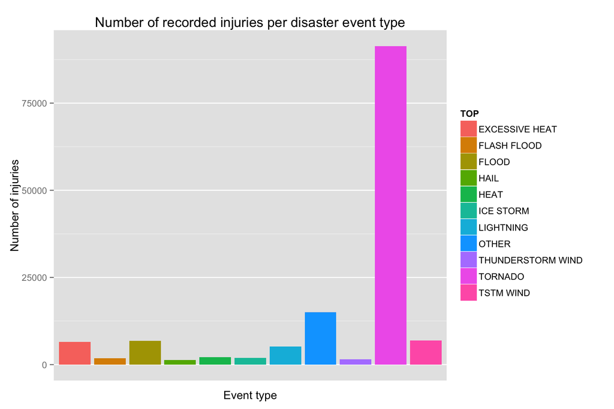

```r
ggplot(injuriesSummarized, aes(x=as.factor(TOP), y=x)) + geom_bar(stat="identity", aes(fill=TOP))  +
    theme(axis.text.x=element_text(angle=-90)) + ggtitle("Number of recorded injuries per disaster event type") +ylab("Number of injuries") + xlab("Event type") + scale_x_discrete(breaks=NULL)
```

Clearly, tornado type events are the most devastating in terms of lost lives and injuries.

### Economic damage by event type

The following panel plot shows the average extimated property and crop damage in USD for the most costly event types.

```r
library(gridExtra)
```

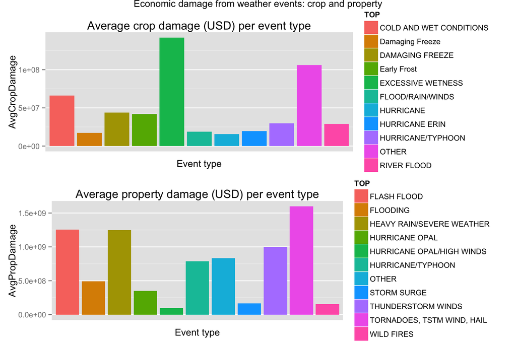

```r
p1<- ggplot(cropDamageSummarized, aes(x=as.factor(TOP), y=AvgCropDamage)) + geom_bar(stat="identity", aes(fill=TOP)) +
xlab("Event type") + ggtitle("Average crop damage (USD) per event type") + scale_x_discrete(breaks=NULL)

p2<- ggplot(propDamageSummarized, aes(x=as.factor(TOP), y=AvgPropDamage)) + geom_bar(stat="identity", aes(fill=TOP)) +
    xlab("Event type")+ ggtitle("Average property damage (USD) per event type") + scale_x_discrete(breaks=NULL)

grid.arrange(p1,p2,main="Economic damage from weather events: crop and property")
```